# EPI 569 – Homework 2: Modeling a directly-transmitted pathogen

Author

Victoria Ngo

```r
library(kableExtra)
library(deSolve)
library(reshape2)
library(ggplot2)
```

## Background 1

- A new pathogen has emerged in the Republic of Zubrowka. Here’s what we know so far:
  - All individuals are initially susceptible and become infected by contact with an infected person
  - People are symptomatic infectious for a while and then become immune
  - Immunity eventually wanes.
- We can partition our population of size (N) into susceptible (S), infected (I), and immune (R) people. So, N = S + I + R. These are our state variables: S, I and R.
- Below, you will draw a diagram of the model and will also write out the model as a system of equations. To do that, we will also need the following information as parameters:
  - $\mu$ is the birth and death rate, maintaining constant population size;
  - $\omega$ is the rate at which immunity is lost;
  - $\sigma$ is the recovery rate, and
  - $\delta_t$ is the interval between successive calculations or time-step.
  - $\lambda$ is the force (or rate) of infection per susceptible person. Which is:
    - contact rate, $\alpha$, multiplied by
    - the probability of infection on contact with an infectious person $\beta$, multiplied by
    - the probability that a randomly encountered person is infectious, $\frac{I_{t-1}}{N}$.

## Question 1 **(1pt)**

- Draw a flow diagram of this transmission process. Include all the state variables (i.e., compartments) and arrows illustrating the flows in and out of the states.
- You can insert the picture into your markdown file using the following code , or just upload as a separate file to Canvas when you turn in your work
- **ANSWER**

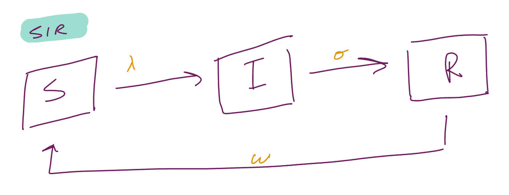

```r
knitr::include_graphics(here::here("02. SIR exercise", "Figure", "q1 sir model.jpg"))
```

## Question 2 **(1pt)**

- Now, write the model down as a system of **differential** equations. You may use the Equation editor in Word, markdown in R/quarto (see [here](https://rmd4sci.njtierney.com/math) for help) or another program of your choosing. You can also hand write and insert a picture.
- *Go through these equations to ensure that you understand what each term implies about the epidemiology of infection. You can also review the formulas in a[n Excel spreadsheet version of this model](https://github.com/blopman/epi569/blob/master/SIR_model_exercise.xlsx). Note that those are difference (not differential) equations*
- **ANSWER**

[figure not shown]

```r
knitr::include_graphics(here::here("02. SIR exercise", "Figure", "q2 sir model.jpg"))
```

## Background 2

- Before moving on, have a look at the Excel spreadsheet version of the model that uses difference equations. In that version, you can easily see what’s going on the model. For the rest of the exercise, we’ll be using an *R* version of the model (below, embedded in this script) that uses differential equations. Add the parameter values to the spreadsheet or *R* script. Use values that seem sensible to you. Remember to keep all in the same units (days). For now, set the waning rate $\omega$ to 0 (this mean that there is lifelong immunity) and the mortality rate $\mu$ to 0 (i.e. no births/ deaths/ migrations).
- *Conceptual note: In models with constant per capita rates, the time spent in a compartment is exponentially distributed, so the mean ‘residence times’ are reciprocals of the exit rates or vice versa. For example,* $\sigma$ is the reciprocal (i.e. 1/d) of the duration of illness.

## Background 3 – Model parameters

- You’ll use the parameter values below for questions 4 and 6

| Parameter | Symbol | Value |
| --- | --- | --- |
| Daily contact rate | $\alpha$ | 5.0 |
| Transmission probability | $\beta$ | 0.1 |
| Recovery rate | $\sigma$ | 0.2 |
| Loss of immunity rate | $\omega$ | 0 |
| Birth and death rate | $\mu$ | 0 |

## Question 3 **(1pt)**

- Another way to express the basic reproduction number is $R_{0}=\frac{\alpha \beta}{\mu +\sigma}$
- Explain this in words. *Hint: What are* $\alpha \beta$ and $\frac{1}{\mu +\sigma}$? Again, remember that the mortality rate ${\mu}$ is zero (so far).
- **ANSWER**

The equation for the basic reproductive number, $R_{0}=\frac{\alpha \beta}{\mu +\sigma}$, can be seen as the daily rate of transmission from the probable contact with an infectious and susceptible person divided by the rate of recovery.

## Question 4 **(1pt)**

- Calculate the basic reproductive number for your model.
- **ANSWER**

$R_{0}=\frac{5.0 * 0.1}{0 + 0.2}$

$R_{0}=2.5$

## Question 5 **(1pt)**

- If the initial conditions are $S_{0}$ = 100, $I_{0}$ = 0, and $R_{0}$ = 0, what does this say about the composition of the population at t = 0?
- **ANSWER**

$N=S + I + R$

$N=100 + 0 + 0$

$N=100$

At time = 0, the population of 100 does not have any infected or recovered individuals.

## Background 4

- Here we have the model in R. It consists of:
  - parameters (*parms*),
  - initial conditions (*init*),
  - the model as ordinary differential equations (*sir_ode*).
- Then the model creates output (*sir_out*) and is graphed (*using ggplot*)

```r
# Define parameters -- THESE ARE THE MODEL PARAMETERS
parms <- c(alpha =5,        # alpha = daily contacts
           beta=0.1,        # beta = probability of infection on contact
           sigma=0.2,       # sigma = rate of recovery per day
           mu = 0.0,        # mu =  per capita birth and death rate
           omega = 0.0)     # omega = rate of immune loss per day

# Initial conditions --  THESE ARE THE CONDITIONS AT THE START OF THE SIMULATION
init <- c(S=99,           # number initially susceptible
          I=1,            # number initially infectious
          R=0)            # initially immune or "recovered"

# Define model equations -- do not change -- or change with care!
# These are the model equations.  They are written as a function called sir_ode.
# "parms" and "init" input the parameters and inital conditions into the equations
sir_ode <- function(times,init,parms){
  with(as.list(c(parms,init)), {
    # ODEs
    dS <- mu*(S+I+R) + omega*R -alpha*beta*I*S/(S+I+R) - mu*S
    dI <- alpha*beta*I*S/(S+I+R)-sigma*I - mu*I
    dR <- sigma*I  - omega*R - mu*R
    list(c(dS,dI,dR))
  })
}

# This creates the output from model equations.
#If you want to run the model for longer, change the second term eg: seq(0,200,...)
times <- seq(0,100,length.out=100)
sir_out <- lsoda(init,times,sir_ode,parms)
sir_out_long <- melt(as.data.frame(sir_out),"time")
```

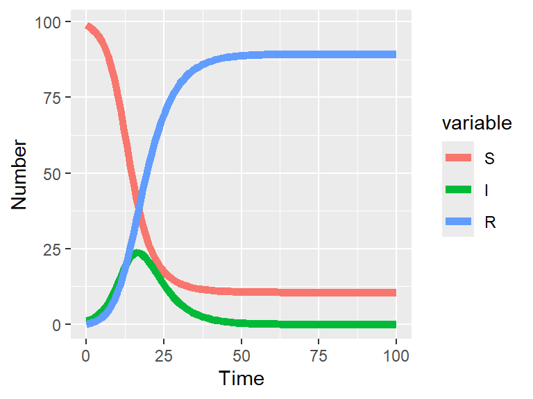

```r
#Plotting the model output
ggplot(sir_out_long,aes(x=time,y=value,colour=variable,group=variable))+
  geom_line(lwd=2)+             #Add line
  xlab("Time")+ylab("Number")   #Add labels
```

- Now, introduce an infectious person by changing $I_{0}$ = 1 and the values from the parameter table above into the model below. Run the model to calculate the number of individuals in S, I, and R compartments from t=1 to t=100. To answer the following questions you can examine the model output in the data frame sir_out and the plot.

## Question 6 **(1pt)**

- When does the epidemic peak? When does it end?
- Does everyone get eventually infected? If not, why? *Hint: Think about this in terms of the **effective** reproductive number* $R_{e}$?
- **ANSWER**

No, not everyone becomes infection as the epidemic progresses. As people recover and become immune, the pool of susceptible individuals shrinks, and the epidemic will slow down and eventually stop due to herd immunity. This natural epidemic progression ensures that only a portion of the population will be infected.

## Question 7 **(1pt)**

- Now, let’s say that some residents of Zubrowka had returned from a neighboring country and had immunity from exposure there. Lower $S_{0}$ to reflect this, but keep the total population size, N, the same.
- Is there a threshold at which an epidemic does not occur? If so, what is it and why? You can solve this mathematically (i.e., analytically) but also try it out in the model.
  - *Hint: Again, consider the effective reproductive number,* $R_{e}$
- **ANSWER**

## Question 8 **(1pt)**

- Set the parameters back to the original values and now add some **simple demography**. Assume that people are entering and leaving the population in a balanced death and birth rate.
- Set the birth and death rate, $\mu$, to 0.1 per day. Also try other values. What happens now? How does changing the birth/death rate, $\mu$, affect $R_{0}$? How does it affect the equilibrium and why?

```r
# Define parameters -- THESE ARE THE MODEL PARAMETERS
parms <- c(alpha =5,        # alpha = daily contacts
           beta=0.1,        # beta = probability of infection on contact
           sigma=0.2,       # sigma = rate of recovery per day
           mu = 0.1,        # mu =  per capita birth and death rate
           omega = 0.0)     # omega = rate of immune loss per day

# Initial conditions --  THESE ARE THE CONDITIONS AT THE START OF THE SIMULATION
init <- c(S=99,           # number initially susceptible
          I=1,            # number initially infectious
          R=0)            # initially immune or "recovered"

# Define model equations -- do not change -- or change with care!
# These are the model equations.  They are written as a function called sir_ode.
# "parms" and "init" input the parameters and initial conditions into the equations
sir_ode <- function(times,init,parms){
  with(as.list(c(parms,init)), {
    # ODEs
    dS <- mu*(S+I+R) + omega*R -alpha*beta*I*S/(S+I+R) - mu*S
    dI <- alpha*beta*I*S/(S+I+R)-sigma*I - mu*I
    dR <- sigma*I  - omega*R - mu*R
    list(c(dS,dI,dR))
  })
}

# This creates the output from model equations.
#If you want to run the model for longer, change the second term eg: seq(0,200,...)
times <- seq(0,100,length.out=101)
sir_out <- lsoda(init,times,sir_ode,parms)
sir_out_long <- melt(as.data.frame(sir_out),"time")
```

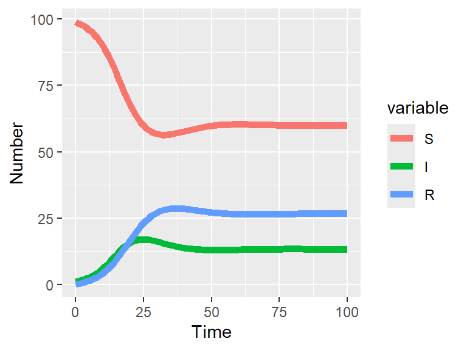

```r
#Plotting the model output
ggplot(sir_out_long,aes(x=time,y=value,colour=variable,group=variable))+
  geom_line(lwd=2)+             #Add line
  xlab("Time")+ylab("Number")   #Add labels
```

- **ANSWER**

As the birth/death rate increases, there is a decrease in infections and recovery in the population due to population size changing.The increased birth/death is also decreasing $R_{0}$, making it harder for the disease to spread as fast. Additionally, the peak of the infection is delayed to time = 25 when $\mu$ > 0.

A non-zero $\mu$ means that the infection can stabilize at a low level in the population due to the constant flow of new susceptibles preventing the disease from dying out. This potentially leads to endemic stability where the disease continues to circulate in the population at manageable levels.

## Question 9 **(1pt)**

- Now, we will also allow immunity to wane by changing $\omega$ to a value greater than 0.
- Choose parameter values that keep $R_{0}$ bigger than 1 (e.g. $\omega$ = 0.05/day). How does adding this extra process affect the dynamics?
- *Hint: You may wish to increase the span of simulation by changing this line of code in the model code below:*
  - times <- seq(0,100,length.out=100) by replacing *100* with *500* days

```r
# Define parameters -- THESE ARE THE MODEL PARAMETERS
parms <- c(alpha =5,        # alpha = daily contacts
           beta=0.1,        # beta = probability of infection on contact
           sigma=0.2,       # sigma = rate of recovery per day
           mu = 0.0,        # mu =  per capita birth and death rate
           omega = 0.05)     # omega = rate of immune loss per day

# Initial conditions --  THESE ARE THE CONDITIONS AT THE START OF THE SIMULATION
init <- c(S=99,           # number initially susceptible
          I=1,            # number initially infectious
          R=0)            # initially immune or "recovered"

# Define model equations -- do not change -- or change with care!
# These are the model equations.  They are written as a function called sir_ode.
# "parms" and "init" input the parameters and initial conditions into the equations
sir_ode <- function(times,init,parms){
  with(as.list(c(parms,init)), {
    # ODEs
    dS <- mu*(S+I+R) + omega*R -alpha*beta*I*S/(S+I+R) - mu*S
    dI <- alpha*beta*I*S/(S+I+R)-sigma*I - mu*I
    dR <- sigma*I  - omega*R - mu*R
    list(c(dS,dI,dR))
  })
}

# This creates the output from model equations.
#If you want to run the model for longer, change the second term eg: seq(0,200,...)
times <- seq(0,500,length.out=500)
sir_out <- lsoda(init,times,sir_ode,parms)
sir_out_long <- melt(as.data.frame(sir_out),"time")
```

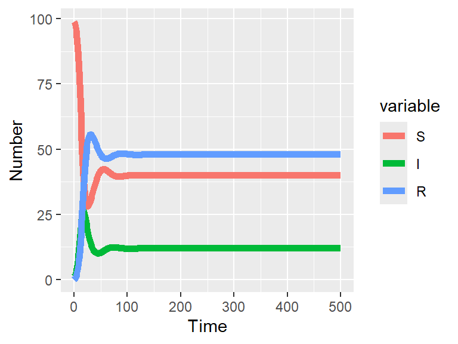

```r
#Plotting the model output
ggplot(sir_out_long,aes(x=time,y=value,colour=variable,group=variable))+
  geom_line(lwd=2)+             #Add line
  xlab("Time")+ylab("Number")   #Add labels
```

## Question 10 **(1pt)**

- $R_{e}$ is defined as the average number of secondary infections produced by an infectious person at any given time *e*. What is the value of $R_{e}$ when the infection has attained the endemic equilibrium? How does the duration of immunity affect $R_{e}$? What does this mean? (0.5pt)
- **ANSWER**

At endemic equilibrium, $R_{e}$ would be equal to 1. The duration of immunity impacts $R_{e}$ by increasing the susceptible population due to reinfection. The reinfection from waning immunity allows the infection to stay in the population as the number in the susceptible population is perpetually changing as people are moving from recovered to susceptible.

## Extensions

- The model(s) you have used so far in this exercise, even though simple, captures quite well many observed patterns of infections in human populations. Still, models can be extended to include a variety of complexities.
- Consider how you would model interventions in this model, such as:
  - social distancing?
  - vaccination?
  - demographic dynamics (i.e. when birth is different that death rate)?
  - an infection with a carrier state?

## Extra credit **(0.5pt)**

- Which of these complexities can be incorporated into the model without structural changes to the model. In other words, what can we incorporate by changing parameter values only and not changing the equations?
- **ANSWER**

To change the parameter values, social distancing can be incorporated to decrease the daily contact rates.